# Script 8: Sharp Regression Discontinuity

Script 8 Spring 2026

# Recap

### Sharp Regression Discontinuity

When working with RDDs, we exploit that treatment assignment is determined by a known **assignment rule** that determines whether units are assigned to the treatment. In the context of an RDD, all units in the study receive a score, usually called *running variable*, *forcing variable* or *index*, and treatment is assigned to those units whose score is above a known cut-off (Cattaneo et al 2019).

In RDD, there generally are three components:

1. The score (of the running variable)
2. The cut-off
3. The treatment.

In the *Sharp Regression Discontinuity Design* (Sharp RDD), the score **fully** determines whether the unit receives treatment or not. However, we again face the fundamental problem of causal inference because we can only observe the untreated outcome for those units below the cut-off (control) and the treated outcome for those above the cut-off (treated). However, imposing the assumption of continuity (that is, comparability of units close to the cut-off) between units with very similar values of the score, but on opposite sides of cut-off, enables us to calculate the treatment effect of the intervention.

Given the continuity assumption, we would expect that observations in a small neighbourhood around the cut-off will have very similar, in expectation equivalent, potential outcomes. Thus, this would justify using observations just below the cut-off as a reasonable proxy for the average outcome for those units just above the cut-off if they had received the control condition instead of the treatment (i.e., as their counterfactual).

The main goal in RDDs thus is to adequately perform an extrapolation of the average outcome of treated and untreated units across the cutoff.

### Estimation

There are different ways that to estimate the causal effect using an RDD:

- Linear
- Linear with different slopes
- High-order polynomial (or non-linear)
- Non-parametric

### Choice of Kernel function and Polynomial Order

Whenever we estimate RDDs, we do the following, either explicitly or implicitly:

1. Select a polynomial order $p$ function
2. Choose kernel function $K(\cdot)$, which determines how observations within a bandwidth would be weighted, usually involving one of the following options: “Uniform”, “Triangular”, and “Epanechnikov”.
3. Bandwidth size, considering the trade-off between bias and variance: the closer you get to the cut-off, the less bias in the estimator, but there is more variance as there are fewer observations.
4. We conduct weighted least squares and obtain the intercept of the chosen polynomial order above and below the cut-off.
5. Calculate the sharp point estimate by subtracting the intercepts of these polynomials: $\hat{\tau_{SRD}} = \alpha_{above} - \alpha_{below}$

### Falsification tests:

We learned that we can conduct multiple sensitivity and falsification tests:

1. Sensitivity: check that the results of our estimation are robust to different specifications.
2. Continuity: verify that covariates do not jump at the threshold.
3. Sorting: check that units do not sort around the threshold.
4. Placebo cut-offs: check that outcomes do not change abruptly at an arbitrary threshold (to lend plausibility to the continuity assumption)

**Before starting this seminar**

1. Create a folder called “script8”
2. Download the data (you can use the button or the one at the top, or read csv files directly from github):
3. Open an R script (or Markdown file) and save it in our “script8” folder.
4. Set your working directory using the setwd() function or by clicking on “More“. For example *setwd(“~/Desktop/Causal Inference/2026/script8”)*
5. Let’s install an load packages that we will be using in this script:

```r
library(stargazer) # generate formated regression tables
library(texreg) # generate formatted regression tables
library(tidyverse) # to conduct some tidy operations
library(ggplot2)
library(rdrobust) # to conduct non-parametric rd estimates
library(rddensity) # to conduct a density test and density plots
library(rdlocrand) # for rdrobust senstitivity checks

# RDD has been removed from CRAN, but  you can download an archived version using the remotes package
#install.packages("remotes")
#remotes::install_url("https://cran.r-project.org/src/contrib/Archive/rdd/rdd_0.57.tar.gz")
# If you had installed rdd before it was removed from CRAN, load it directly
library(rdd) # to conduct McCrary Sorting Test
```

# Seminar Overview

In this **seminar**, we will cover the following topics:  
1. Conduct regression discontinuity using (global) polynomial estimation using the `lm()` function  
2. Calculate LATE using non-parametric estimations using `rdrobust()`.  
3. Conduct various robustness/falsification tests such as balance tests, placebo outcome, density tests, and sensitivity tests.

## Islamic Rule and the Empowerment of the Poor and Pious - Meyerson (2014)

In this [paper](https://onlinelibrary.wiley.com/doi/abs/10.3982/ECTA9878), Meyerson is interested in the effects of Islamic parties’ control of local governments on society in general and women’s rights specifically. He focuses on the educational attainment of young women. Meyerson conducts a sharp RD design, based on close elections in Turkey. The challenge here is to compare municipalities where the support for Islamic parties rather is high and they win the election, versus those that elected a secular mayor.

You would expect that municipalities controlled by Islamic parties would systematically differ from those that are controlled by a secular mayor. Especially so if religious/social conservatism affects the educational outcomes of women - for which reason any naive approach is bound to fail at estimating the effect. However, we can resort to RDD to isolate the treatment effect of interest from all systematic differences between treated and untreated units.

We can compare municipalities where an Islamic party barely won the election versus municipalities where the Islamic party barely lost. This reveals the causal (local) effect of Islamic party control on women’s educational attainment a few years later. One crucial condition to meet in this set-up is that parties cannot systematically manipulate the vote share they obtain. An important yet fairly straightforward assumption that can be expected to hold if electoral integrity is guaranteed.

The data used in this study is from the 1994 mayoral election in Turkey. The unit of analysis is the municipality, and the running variable is the margin of victory. The outcome of interest is the educational attainment of women who attended high school during 1994-2000, calculated as a percentage of the cohort of women aged 15 to 20 in 2000 who had completed high school by 2000.

We will be using the following variables:

| Variable | Description |
| --- | --- |
| `margin` | This variable represents the margin of victory of Islamic parties in the 1994 election. A positive margin means that an Islamic party won. |
| `school_men` | secondary school completion rate for men aged 15-20 |
| `school_women` | secondary school completion rate for women aged 15-20 |
| `log_pop` | log of the municipality population in 1994 |
| `sex_ratio` | gender ratio of the municipality in 1994 |
| `log_area` | log of the municipality area in 1994 |

Now let’s load the data. There are two ways to do this:

You can read the data directly from github or load the dataset from your laptop using the `read.csv()` function. Here the dataset is called `educ` - but feel free to give it a different name if you prefer.

```r
# Set your working directory
#setwd("~/Desktop/Causal Inference/2026/script8")
#
library(readr)
#educ <- read.csv("~/islamic_women.csv")

head(educ)
```

```
# A tibble: 6 × 6
  margin school_men school_women log_pop sex_ratio log_area
   <dbl>      <dbl>        <dbl>   <dbl>     <dbl>    <dbl>
1 -0.356      0.379        0.230    8.00     0.977     11.2
2 -0.543      0.309        0.254    7.36     1.12      10.6
3 -0.204      0.226        0.227   13.2      0.975     NA
4 -0.450      0.171        0.159    7.62     1.03      10.9
5 -0.201      0.173        0.182    7.65     1.18      11.5
6 -0.506      0.266        0.25     7.31     1.02      10.3
```

Let’s start by visualising the data. We will use the `plot()` function to do this. This is the simplest scatter plot that you can come up with.

**Exercise 1: Generate a plot using the `plot(X,Y)` function. Replace X with `educ$margin` and Y with `educ$school_women`. You may want to add axes labels.**

**Reveal Answer**

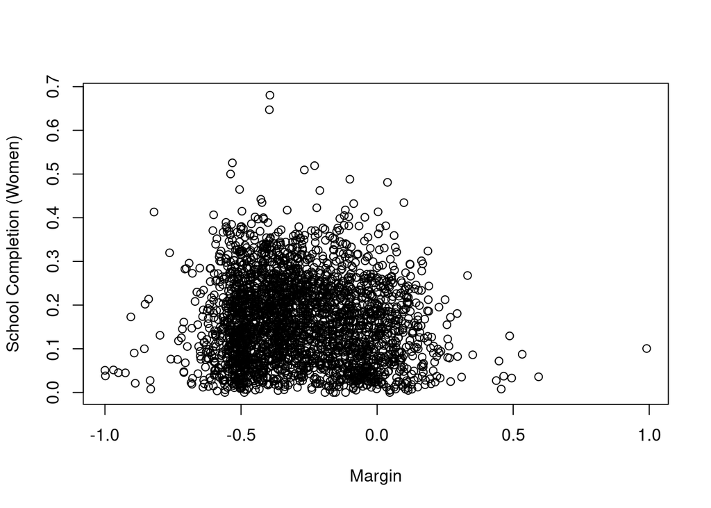

```r
plot(educ$margin, educ$school_women,
     xlab="Margin", ylab="School Completion (Women)")
```

This is a very simple plot that shows the raw relationship between the margin of victory and the outcome variable. However, it conveys some important information. For example, the margin of victory is clustered between -0.5 and roughly 0.3. Also, the outcome variable, school attainment, usually ranges from 0 to 40%. Now let’s generate a slightly fancier plot.

**Exercise 2: Generate a scatter plot using the `ggplot()` function. Use the functions below to add some additional features to this plot.**

```r
ggplot(aes(x = running variable, y = outcome, colour =outcome), data = data) +
  # Make points small and semi-transparent since there are lots of them
  geom_point(size = 0.5, alpha = 0.5, position = position_jitter(width = 0, height = 0.25, seed = 1234)) +
  # Add vertical line
  geom_vline(xintercept = 0) +
  # Add labels
  labs(x = "Label X", y = "Label Y") +
  # Turn off the color legend, since it's redundant
  guides(color = FALSE)
```

**Reveal Answer**

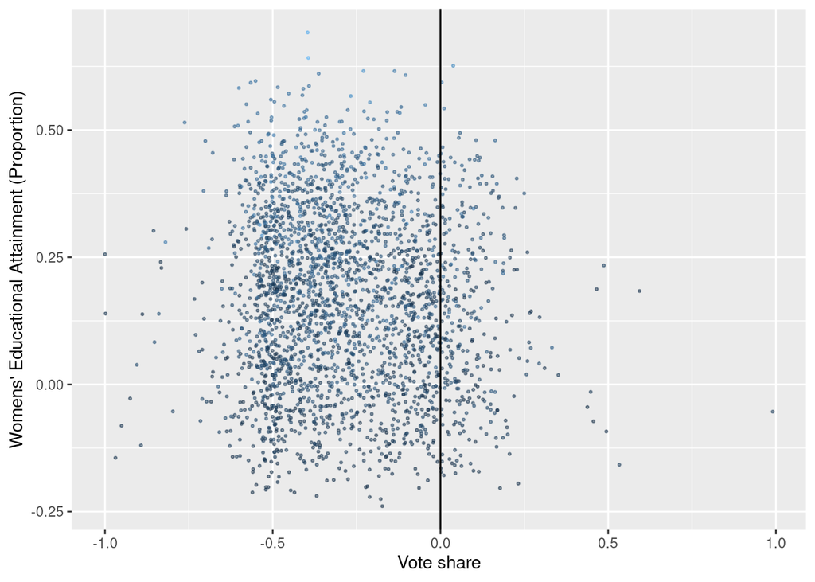

```r
ggplot(educ, aes(x = margin, y = school_women, colour =school_women)) +
  # Make points small and semi-transparent since there are lots of them
  geom_point(size = 0.5, alpha = 0.5,
             position = position_jitter(width = 0, height = 0.25, seed = 1234)) +
  # Add vertical line
  geom_vline(xintercept = 0) +
  # Add labels
  labs(x = "Vote share", y = "Womens' Educational Attainment (Proportion)") +
  # Turn off the color legend, since it's redundant
  guides(color = FALSE)
```

We can now see more clearly that most municipalities elected a secular mayor, seeing the difference between the Islamic parties’ vote share and the secular parties’ ones. Recall that we are using the margin of victory for the Islamic parties - a positive margin of victory means that the Islamic parties won the election in that municipality, whereas a negative margin indicates a loss for the Islamic party. There are only few municipalities where Islamic parties won with a wide margin, while there are quite a few where they lost at a distance.

**Exercise 3: Let’s generate a dummy factor variable that takes on the string “Treated” if the margin of victory *is equal to or greater than zero* and “Untreated” otherwise, making sure that those strings are associated with the levels 1 and 0, respectively. You can use the `mutate()` function and the `ifelse()` functions to do this. Remember to use the pipeline operator to store the variable into your existing data frame. See below the general syntax for more information.**

| Function/argument | Description |
| --- | --- |
| `data <- data %>%` | Pipeline operator to assign the new operation to a new or existing data frame |
| `mutate(new variable = ifelse(variable >= "condition", Treated, Untreated)` | If the condition is met, the new variable takes on the value “Treated” or, otherwise, “Untreated” |
| `factor()` | Create a factor variable based on an existing variable and assign labels to levels |

```r
data <- data %>%
  mutate(newvariable = ifelse(variable >=1, 1, 0))


data$newvarfactor <- factor(data$newvariable, levels=c(0,1), labels=c("Untreated", "Treated"))
```

**Reveal Answer**

```r
educ <- educ %>%
  mutate(treat = ifelse(margin >= 0 , 1, 0))

# optionally assign the corresponding labels to the treat variable

educ$treat_f <- factor(educ$treat, levels=c(0,1), labels=c("Untreated", "Treated"))
```

Now that we have created our treatment condition variable, let’s generate an additional plot that conveys information on the distribution of the running variable for both treated and untreated municipalities.

**Exercise 4: Generate a plot looking at the distribution of the running variable. Using the `ggplot()` function, set the `x` argument equal to the margin of victory variable. Set `fill` equal the new treatment variable `treat_f`. There is no need to add the `y` argument given that we expect to generate a histogram that will give us the number of observations for each value in the margin of victory variable. Add the `geom_histogram()` function. Set the argument `binwidth` in this function equal to 0.01 and set `colour` argument equal to “white”. Let’s add the `geom_vline()` function to add a vertical line by setting the `xintercept` argument equal to zero. Add the `labs()` function and set `x` label equal to “Margin of victory” and the `y` label equal to “count”, and the `fill` argument equal to “Treatment Status”.**

**Reveal Answer**

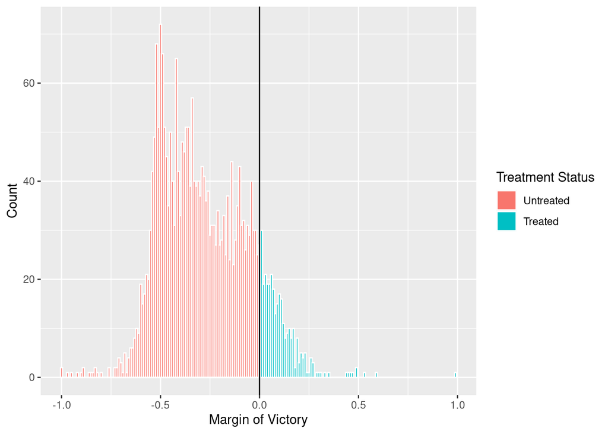

```r
ggplot(educ, aes(x = margin, fill = treat_f)) +
  geom_histogram(binwidth = 0.01, color = "white") +
  geom_vline(xintercept = 0) +
  labs(x = "Margin of Victory", y = "Count", fill = "Treatment Status")
```

In this plot, we can see the distribution of the running variable (*margin of victory*). Again, we can see that in the majority of the municipalities a secular mayor was elected. Extremely clear elections are rare, but there are a few cases where the secular party got almost all the votes. The most frequent outcomes cluster around a margin of victory of `-0.5`, implying a vote share of about 25% for the Islamic party and 75% for the secular party, for instance.

## Global Parametric Estimation

As we discussed in the lecture, there are different ways to estimate the causal effect using RD. These different approaches differ in the range of observations they include as well as in how exactly they estimate the average outcome for those units just above the cut-off and below the cut-off. The most parsimonious way to estimate the effect of the intervention in RDD is using OLS, and doing so only using the running variable as the main predictor. In this case, we use the centred running variable - i.e., measured as the distance from the cut-off. Stated formally: $\tilde{X} = X - c$.

In this case, the regression on the left-hand side would be equal to:

$$Y= \alpha_l + \beta_{l} \tilde{X} +
\epsilon$$
Whereas the regression above the cut-off is equal to:

$$Y= \alpha_r + \beta_{r} \tilde{X} +
\epsilon$$
It’s important to point out that for all estimations the treatment effect is equal to the difference between the intercepts of the regressions above and below the cut-off.

$$\tau = \alpha_r - \alpha_l$$

Let’s do this manually. To do so, subset the data for those observations above and below the threshold, respectively. Then, regress the outcome on the **running variable**. Finally, subtract the intercepts from each regression. Let’s do that in the following exercise.

**Exercise 5: Run two regressions using only the `margin` variable as the predictor. The outcome variable is `school_women`. Set the `data` argument equal to `educ` (unless you called your data frame differently). Add the `subset` function inside of the `lm()` function and set it equal to `margin >= 0` for the regression above the cut-off and `margin < 0` for the regression below the cut-off. Use the `summary()` function to report your results, but also store the outputs of this function into two objects. You can retrieve the intercept from the object that you stored the output from the `summary()` function this way:**

```r
object <- summary(lm(outcome ~ variable, data = data, subset = variable >= condition))

# intercept
object$coefficient[1]
```

**Reveal Answer**

```r
# above
above <- summary(lm(school_women~margin, data = educ, subset = margin >= 0))

above$coefficients[1]
```

```
[1] 0.1564529
```

```r
# above
below <- summary(lm(school_women~margin, data = educ, subset = margin < 0))

below$coefficients[1]
```

```
[1] 0.1620016
```

```r
# 0.156453 - 0.162002
tau_rd = above$coefficients[1] - below$coefficients[1]
tau_rd
```

```
[1] -0.00554867
```

Based on this approach the intercepts of the two regressions yield the estimated value of the average outcome at the cut-off point for the treated and untreated units. This difference between intercepts is the estimated effect of an Islamic party being in power (at the municipal level) - it suggests there is a 0.6 percentage point decrease in women’s educational attainment.

A more direct way of estimating the treatment effect is to run a pooled regression on both sides of the cut-off point, using the following specification:
$$Y = \alpha + \tau
D + \beta \tilde{X} + \epsilon$$

Where $\tau$ is the coefficient of interest. Here again `LATE` is equivalent to the difference between the two intercepts ($\tau = \alpha_r -\alpha_l$), but we impose the same slope on either side of the cut-off. When $D$ ‘switches off’ and we are only controlling for the centred forcing variable, $\tilde{X}$, we get the intercept of the regression ‘just below’ the threshold. Conversely, for units at the cut-off, $D$ switches on, and we get the intercept of the regression above the cut-off. The estimated effect of the treatment at $\tilde{X}=0$ then provides the treatment effect ($\tau$).

The slope remains constant for all values of the forcing variable, hence, you are constraining the slope of the regression lines to the same on both sides of the cut-off ($\beta = \beta_l = \beta_r$). This might not be sensible if the data structure varies and the single slope fails to appropriately approximate either side of the cutoff.

**Exercise 6: Calculate the effect of the treatment using a regression model including the `margin` and `treat_f` variables. Use the`lm()` function to conduct this analysis. Store this regression into an object and call it `global2`. Use the `summary()` to inspect your results. Interpret the coefficient of interest.**

**Reveal Answer**

```r
# a more direct way is to run a pooled regression on both sides of the cut-off (constraining the slopes)

global2 <- lm(school_women~treat_f+margin, data = educ)
summary(global2)
```

```
Call:
lm(formula = school_women ~ treat_f + margin, data = educ)

Residuals:
     Min       1Q   Median       3Q      Max
-0.17051 -0.07650 -0.00691  0.06527  0.51306

Coefficients:
                Estimate Std. Error t value Pr(>|t|)
(Intercept)     0.159705   0.004162  38.369   <2e-16 ***
treat_fTreated -0.017347   0.007467  -2.323   0.0202 *
margin         -0.019321   0.010967  -1.762   0.0782 .
---
Signif. codes:  0 '***' 0.001 '**' 0.01 '*' 0.05 '.' 0.1 ' ' 1

Residual standard error: 0.09543 on 2627 degrees of freedom
  (574 observations deleted due to missingness)
Multiple R-squared:  0.008805,  Adjusted R-squared:  0.00805
F-statistic: 11.67 on 2 and 2627 DF,  p-value: 9.016e-06
```

Using this estimation approach, we obtain that, on average, the effect of a municipality being governed by an Islamic party leads to a 1.7%-point decrease in women’s educational attainment.

We can also allow the regression function to differ on either side of the cut-off, simply by including an interaction term between $D$ and $\tilde{X}$. In fact, this would be advisable if the data structure differs for any reason. This would look as follows:

$$Y = \alpha_l + \tau D + \beta_0\tilde{X}
+ \beta_1 (D \times\tilde{X})+ \epsilon$$

Let’s do that in the following exercise.

**Exercise 7: Calculate the effect of the treatment using a regression model including the `margin` and `treat_f` variables and the interaction between these two variables. Use the`lm()` function to conduct this analysis. Store this regression into an object and call it `global3`. Use the `summary()` to inspect your results. Interpret the coefficient of interest.**

**Reveal Answer**

```r
global3 <- lm(school_women~treat_f+margin + treat_f*margin, data = educ)
summary(global3)
```

```
Call:
lm(formula = school_women ~ treat_f + margin + treat_f * margin,
    data = educ)

Residuals:
     Min       1Q   Median       3Q      Max
-0.16896 -0.07655 -0.00723  0.06561  0.51348

Coefficients:
                       Estimate Std. Error t value Pr(>|t|)
(Intercept)            0.162002   0.004237  38.237  < 2e-16 ***
treat_fTreated        -0.005549   0.008561  -0.648  0.51697
margin                -0.012439   0.011224  -1.108  0.26787
treat_fTreated:margin -0.144062   0.051352  -2.805  0.00506 **
---
Signif. codes:  0 '***' 0.001 '**' 0.01 '*' 0.05 '.' 0.1 ' ' 1

Residual standard error: 0.09531 on 2626 degrees of freedom
  (574 observations deleted due to missingness)
Multiple R-squared:  0.01177,   Adjusted R-squared:  0.01064
F-statistic: 10.42 on 3 and 2626 DF,  p-value: 8.144e-07
```

Note that this is equivalent to the most simple approach we calculated above by subtracting two intercepts. Here, we find that the coefficient of interest is negative (`-0.006`) yet insignificant. This means that, based on this model, the effect of an Islamic party in control of the municipal government does not lead to a change in women’s educational attainment.

Global parametric models have a severe shortcoming, however - they rely upon observations that are far away from the cut-off. This means we compare *all* units - no matter how they relate to the cut-off. Keep in mind that this is not theoretically sound as we already established that municipalities with strong (weak) Islamic party support are likely to be very different from others - thus bringing back in selection bias.

Indeed, the evidence against using a global polynomial approach is quite substantial. According to Cattaneo et al. (2019), this estimation technique neither provides accurate point estimators nor exhibits satisfactory statistical properties.

**Exercise 7b (no coding required): Think about how the global polynomial approach weights each observation when it calculates the coefficient of interest. Is that what we want it to do?**

**Reveal Answer**

OLS will estimate $\tau$ based on all observations across the score. This means the weight of observations very far from the cut-off is equal to that of very close ones. In the worst-case scenario, if the observations are clustered far from the cut-off, the estimation of $\tau$ would be heavily influenced by those values rather than those close to the cut-off.

We can, in theory, also use high-order polynomials to retrieve the LATE. However, the evidence against using high-order polynomials seems to be quite robust [(see here for an extensive discussion on high-order polynomials)](https://www.tandfonline.com/doi/abs/10.1080/07350015.2017.1366909). In short, the issue with using high-order polynomials is that they lead to noisy estimates, they are sensitive to the degree of the polynomial, and they have poor coverage of confidence intervals. And these are issues beyond overfitting and limited external validity of any findings. So, be cautious with everything beyond quadratic control functions!

**Exercise 8: Well - let’s give it a try nonetheless, just to see how it would work. Conduct a third-order polynomial regression function. Include in this model the `treat_f` and the `margin` variables. Also, add the `margin` variable raised at the power of 2 and then at the power of 3. We also need to include the `I()` function or insulate function for the quadratic and cubic terms of the `margin` variable. The `I()` function insulates whatever is inside this function. Here, it creates a new predictor that is the product of the margin variable to the power of two and three, respectively. Store this output in an object and call that object `global4`. Then, use the `summary()` function to check the results of this specification. Interpret the results.**

**Reveal Answer**

```r
global4 <- lm(school_women~ treat_f + margin+I(margin^2)+ I(margin^3) , data = educ)

summary(global4)
```

```
Call:
lm(formula = school_women ~ treat_f + margin + I(margin^2) +
    I(margin^3), data = educ)

Residuals:
     Min       1Q   Median       3Q      Max
-0.17226 -0.07581 -0.00592  0.06335  0.50378

Coefficients:
                Estimate Std. Error t value Pr(>|t|)
(Intercept)     0.138623   0.004947  28.022  < 2e-16 ***
treat_fTreated  0.021484   0.008893   2.416  0.01577 *
margin         -0.179024   0.023219  -7.710 1.77e-14 ***
I(margin^2)    -0.134706   0.037469  -3.595  0.00033 ***
I(margin^3)     0.190585   0.046510   4.098 4.30e-05 ***
---
Signif. codes:  0 '***' 0.001 '**' 0.01 '*' 0.05 '.' 0.1 ' ' 1

Residual standard error: 0.09434 on 2625 degrees of freedom
  (574 observations deleted due to missingness)
Multiple R-squared:  0.03201,   Adjusted R-squared:  0.03054
F-statistic:  21.7 on 4 and 2625 DF,  p-value: < 2.2e-16
```

Using a high-order polynomial function (with the same control function above and below the cut-off), we find that womens’ educational attainment increases, on average, by roughly `2.1` percentage points when an Islamic party is in power.

You might have reason to prefer parametric approaches, or deem them more appropriate in some cases - for instance, if you know the data structure well. Even if this is the case, you should not resort to a global model that considers all observations. It’s more appropriate to only use observations that are close to the cut-off (above and below). Let’s run the unconstrained model from **Exercise 7**, but this time we only use observations that are within 50 percentage points above and below the threshold.

**Exercise 9: Run the same model used in `Exercise 7`, but subset your data to observations only that are no more than 0.5 away from the threshold, below or above.. Store the results from this regression into an object and call it `local`. Use the `summary()` function to check your results. See the syntax below.**

```r
lm(outcome ~ variable1 + variable2 + variable1 * variable2, data=data,
           subset=(running_variable>=-0.5 & running_variable<=0.5))
```

**Reveal Answer**

```r
local <- lm(school_women ~ margin + treat_f + treat_f * margin, data=educ,
           subset=(margin>=-0.5 & margin<=0.5))
summary(local)
```

```
Call:
lm(formula = school_women ~ margin + treat_f + treat_f * margin,
    data = educ, subset = (margin >= -0.5 & margin <= 0.5))

Residuals:
     Min       1Q   Median       3Q      Max
-0.18414 -0.07517 -0.00407  0.06421  0.50304

Coefficients:
                       Estimate Std. Error t value Pr(>|t|)
(Intercept)            0.148888   0.004676  31.841  < 2e-16 ***
margin                -0.072244   0.014916  -4.843 1.37e-06 ***
treat_fTreated         0.010577   0.009179   1.152   0.2493
margin:treat_fTreated -0.118165   0.062268  -1.898   0.0579 .
---
Signif. codes:  0 '***' 0.001 '**' 0.01 '*' 0.05 '.' 0.1 ' ' 1

Residual standard error: 0.09352 on 2174 degrees of freedom
  (574 observations deleted due to missingness)
Multiple R-squared:  0.02567,   Adjusted R-squared:  0.02432
F-statistic: 19.09 on 3 and 2174 DF,  p-value: 3.224e-12
```

We can see that using a local polynomial function, we find that the effect of Islamic rule is null. We would conclude that there is no effect.

It is important to stress that modern empirical work using RDDs empirical work employs local polynomial methods. In this case, we are estimating the average outcomes for treated and untreated units using observations that are near the cut-off, weigh them accordingly, and account for potential problems when it comes to the estimation of measures of uncertainty. This approach tends to be more robust and less sensitive to boundary and overfitting problems. In the following section, we will look at how to use the approach using a non-parametric estimation strategy.

## Non-Parametric Estimation

Let’s now estimate the LATE using a non-parametric estimator. Conveniently, we can easily do so by using the `rdrobust` package. As the name indicates, the package allows us to estimate robust measurements of uncertainty such as standard errors and confidence intervals. It is based on theoretical and technical work by Calonico, Cattaneo and Titiunik. `rdrobust` estimates robust bias-corrected confidence intervals that address the problem of undersmoothing (i.e., too narrow bandwidths) conventional confidence intervals face in RDDs - simply speaking, a small bias would be required for them to be valid, which might not always be the case. Moreover, they also address the poor performance of (non-robust) bias-corrected confidence intervals.

As suggested by the authors and somewhat counterintuitively, we therefore generally use the point estimate provided by the conventional estimator, but robust standard errors, confidence intervals and p-values to make statistical inferences.

The `rdrobust` command has the following minimal syntax. You can use a uniform bandwidth or specify two different ones. We will work with further arguments later. Note that you do not need to specify whether the running variable is centred on the cut-off as you can manually specify the cut-off using the `c`-argument.

```r
robust_model = rdrobust(data$dependent_var, data$running_var,
                       c=[cutoff], h=[bandwidth])
```

**Exercise 10: Estimate the LATE using `rdrobust` with a bandwidth of 5%-points on either side of the cutoff. Interpret your result.**

**Reveal Answer**

```r
robust_5=rdrobust(educ$school_women, educ$margin, c=0, h=0.05)
summary(robust_5)
```

```
Call: rdrobust

Number of Obs.                 2630
BW type                      Manual
Kernel                   Triangular
VCE method                       NN

Number of Obs.                 2315          315
Eff. Number of Obs.             148          109
Order est. (p)                    1            1
Order bias  (q)                   2            2
BW est. (h)                   0.050        0.050
BW bias (b)                   0.050        0.050
rho (h/b)                     1.000        1.000
Unique Obs.                    2313          315

=============================================================================
        Method     Coef. Std. Err.         z     P>|z|      [ 95% C.I. ]
=============================================================================
  Conventional     0.023     0.027     0.848     0.396    [-0.030 , 0.075]
        Robust         -         -     0.774     0.439    [-0.049 , 0.112]
=============================================================================
```

Note that the output indicates the specific bandwidth, the number of observations that fall within the bandwidth and the kernel (triangular is the default). Our point estimate is `0.023`. That is, a victory of an Islamic party would be associated with an increase in the rate of women who complete school by `2.3%-points` - however, the p-value and confidence intervals indicate that the estimate is not statistically significant. Therefore, based on this model, we would conclude that winning an election does *not* have a an effect on female educational attainment.

A bandwidth of 5% seems about reasonable. But we should better check different ones, too. Let’s see what happens if we halve the bandwidth.

**Exercise 11: Estimate the same model as before with a bandwidth of 2.5%-points. Report and interpret your results.**

**Reveal Answer**

```r
robust_25=rdrobust(educ$school_women, educ$margin, c=0, h=0.025)
summary(robust_25)
```

```
Call: rdrobust

Number of Obs.                 2630
BW type                      Manual
Kernel                   Triangular
VCE method                       NN

Number of Obs.                 2315          315
Eff. Number of Obs.              68           62
Order est. (p)                    1            1
Order bias  (q)                   2            2
BW est. (h)                   0.025        0.025
BW bias (b)                   0.025        0.025
rho (h/b)                     1.000        1.000
Unique Obs.                    2313          315

=============================================================================
        Method     Coef. Std. Err.         z     P>|z|      [ 95% C.I. ]
=============================================================================
  Conventional     0.027     0.040     0.691     0.490    [-0.050 , 0.105]
        Robust         -         -    -0.333     0.739    [-0.145 , 0.103]
=============================================================================
```

Well, we can see that the number of observations used to estimate the effect has been reduced - which is expected but we should be aware of this and always consider whether we have a sufficient number of observations. The point estimate did not change much and, as before, we find that there seems to be, in fact, no significant effect at the cut-off.

Bandwidths of 5%-points or 2.5%-points around the cut-off seem somewhat reasonable in this case - but so would several others. How can we know what bandwidth we should use to estimate our effect of interest?

Recall the trade-off we are facing when choosing bandwidths that was discussed in the lecture: on the one hand, we know that narrower bandwidths are associated with less biased estimates. We rely on units that are indeed comparable - with their distance in the running variable being indeed as-if random the closer we get to the cut-off. On the other hand, the narrower the bandwidths, the larger the variance and our estimates will be ever more contingent on a small number of influential observations. As in several cases before, the structure of our data, such as the number of observations, plays an important role. Even if small bandwidths are desirable, it can be difficult [impossible] to estimate a robust and significant effect if the number of observations around the cut-off is very small - even if there is a *true* effect.

Luckily, the `rdrobust` package provides a remedy for this. The packages allows us to specify that we want to use bandwidths that are optimal given the data input. The `rdrobust` command then picks the bandwidth that optimises the *mean squared error* - in other words, *MSE-optimal* bandwidths. Note that this is the default bandwidth if you don’t specify any. Let’s try to find out what this would be in our case.

**Exercise 12: Estimate the LATE using `rdrobust` and MSE-optimal bandwidths. To specify the model, replace the `h` argument with `bwselect="mserd"`.**

**Reveal Answer**

```r
robust_mserd=rdrobust(educ$school_women, educ$margin, c=0, bwselect="mserd")
summary(robust_mserd)
```

```
Call: rdrobust

Number of Obs.                 2630
BW type                       mserd
Kernel                   Triangular
VCE method                       NN

Number of Obs.                 2315          315
Eff. Number of Obs.             529          266
Order est. (p)                    1            1
Order bias  (q)                   2            2
BW est. (h)                   0.172        0.172
BW bias (b)                   0.286        0.286
rho (h/b)                     0.603        0.603
Unique Obs.                    2313          315

=============================================================================
        Method     Coef. Std. Err.         z     P>|z|      [ 95% C.I. ]
=============================================================================
  Conventional     0.030     0.014     2.116     0.034     [0.002 , 0.058]
        Robust         -         -     1.776     0.076    [-0.003 , 0.063]
=============================================================================
```

This now looks very different. We estimate a LATE of about `3%`, which is significant at the 90% confidence level. Note that the optimal bandwidths has been estimated to be `17.2%-points` on either side of the cut-off, with a separate optimal bandwidth for bias correction. Note that the *MSE-optimal* bandwidth is optimal from a statistical point of view - but we should always make sure to asses the bandwidths against our theory. Here, we’d compare parties’ winning margins up to `17%-points`.

Note that, so far, we have used a single bandwidth for data below and above the cut-off. We can also specify different ones - both manually and in terms of optimal bandwidths. As the structure of our data might differ, different bandwidths might be optimal. We can specify two different *MSE-optimal* bandwidth selectors by specifying `bwselect="msetwo"`.

**Exercise 13: Estimate the LATE using `rdrobust` and two MSE-optimal bandwidths. Interpret your results and compare them to the model with a single optimal bandwidth.**

**Reveal Answer**

```r
robust_msetwo=rdrobust(educ$school_women, educ$margin, c=0, bwselect="msetwo")
summary(robust_msetwo)
```

```
Call: rdrobust

Number of Obs.                 2630
BW type                      msetwo
Kernel                   Triangular
VCE method                       NN

Number of Obs.                 2315          315
Eff. Number of Obs.             607          267
Order est. (p)                    1            1
Order bias  (q)                   2            2
BW est. (h)                   0.200        0.174
BW bias (b)                   0.323        0.297
rho (h/b)                     0.619        0.584
Unique Obs.                    2313          315

=============================================================================
        Method     Coef. Std. Err.         z     P>|z|      [ 95% C.I. ]
=============================================================================
  Conventional     0.030     0.014     2.134     0.033     [0.002 , 0.057]
        Robust         -         -     1.810     0.070    [-0.002 , 0.062]
=============================================================================
```

This now looks pretty similar to the single optimal bandwidth, which is a good sign. In fact, the optimal bandwidth for data points above the cut-off remains virtually unchanged. For the ones below the cut-off, the bandwidths is slightly extended. The point estimate and measures of uncertainty also remain virtually unchanged. If specifying two optimal bandwidths alters the results significantly, this is an indicator that the data should be inspected closely for the cause of the diverging bandwidths.

### Kernels

One of the advantages of the non-parametric RDD is that observations can be weighted based on their proximity to the cut-off. This is based on the basic idea that those observations closer to the cut-off provide better comparisons than those farther away. Think of victory margins as a running variable: if we look at fractions of %-points around the cut-off, it is fair to say that victory is *as-if random*. The farther away we move, the less plausible this statement becomes.

As you learned in the lecture, there are different ways to do this. The default kernel used by the `rdrobust` package is a *triangular* kernel - which continuously assigns larger weights to observations closer to the cut-off. This is the one we have been using so far as we didn’t explicitly specify the kernel. As the figure below shows, other possible options include *epachnechnikov* and *uniform* kernels. These can be specified via the `kernel` argument.

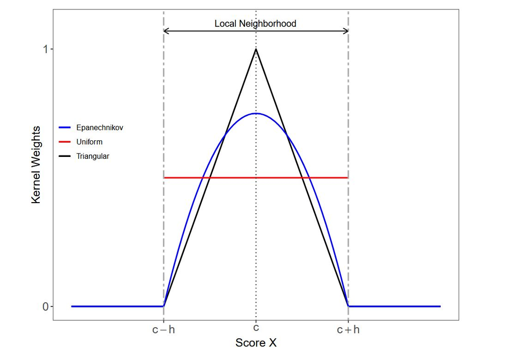

**Exercise 14: Estimate the LATE using `rdrobust` and a single MSE-optimal bandwidth but specify a uniform kernel. Interpret your results.**

**Reveal Answer**

```r
robust_uniform=rdrobust(educ$school_women, educ$margin, c=0, bwselect="mserd", kernel="uniform")
summary(robust_uniform)
```

```
Call: rdrobust

Number of Obs.                 2630
BW type                       mserd
Kernel                      Uniform
VCE method                       NN

Number of Obs.                 2315          315
Eff. Number of Obs.             474          251
Order est. (p)                    1            1
Order bias  (q)                   2            2
BW est. (h)                   0.154        0.154
BW bias (b)                   0.283        0.283
rho (h/b)                     0.546        0.546
Unique Obs.                    2313          315

=============================================================================
        Method     Coef. Std. Err.         z     P>|z|      [ 95% C.I. ]
=============================================================================
  Conventional     0.032     0.014     2.360     0.018     [0.005 , 0.059]
        Robust         -         -     2.044     0.041     [0.001 , 0.063]
=============================================================================
```

As compared to the *triangular* kernel, our point estimate is slightly larger and we find that our robust measures of uncertainty show that the effect is significant at the 95% level. Note that the optimal bandwidth is slightly narrower in the model with a *uniform* kernel. We have to be aware that this model is less conservative though: we assign the same weight to each observation, independent of its distance to the cut-off - which introduces growing bias over increasing bandwidths. Models with triangular kernel are therefore generally preferable.

## Falsification Checks

### Sensitivity

If you estimate an RDD, you should always make sure that results are robust to different specifications of the model. Importantly, this involves *sensitivity checks*. This means you should make sure that results are robust across model specifications and, importantly, different bandwidths.

While there are packages that help produce useful plots that visualise robustness across bandwidths, they can be cumbersome to adjust and often are not very flexible. Hence, one avenue to create such a plot can be to loop `rdrobust` models over different bandwidths. This solution involves somewhat more coding, but gives you a lot of flexibility as to what you want to display and highlight in your output.

**Exercise 15: Create a plot that shows point estimates and confidence intervals for estimates of the treatment effect across different bandwidths.**

There are several ways to do this. Feel free to play around a bit and try to come up with your own way.

**Reveal Hint**

Hint: You could use the following approach:  
- Create a data frame with all variables you need for the plot and an observation for each bandwidth.  
- Extract the values from the `rdrobust` output which you need for your plot.  
- Loop the regression and the extraction of output over the bandwidths indicated in the initial data frame.  
- Save the output from your loop to the respective row in the data frame.  
- Plot the output from the newly created data frame.

**Reveal Answer**

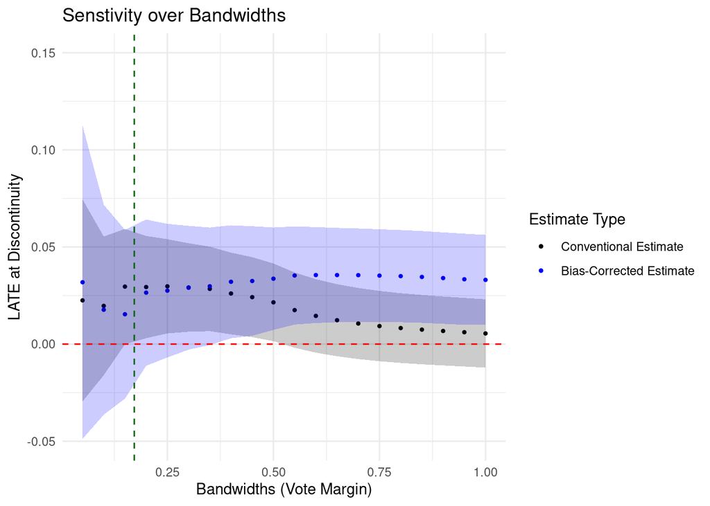

```r
bandwidth <-  seq(from = 0.05, to = 1, by = 0.05)  #create a vector with values for each bandwidth you want to estimate, here we start at 0.05 and move in steps of 0.05 to 1.

# Next, we create empty vectors for all variables
coefficient<- NA
coefficient_corrected<- NA
se <- NA
obs <- NA
bw <- NA
ci_u <- NA
ci_l <- NA
r_ci_u <- NA
r_ci_l <- NA

data_extract <- data.frame(bandwidth, coefficient, coefficient_corrected, se, obs, bw, ci_u, ci_l, r_ci_u, r_ci_l) # we then create a data.frame with all variables we want to incldue in your dataset

# Specify MSE-optimal bandwidth
mserd <- 0.172 ### we know this from the exercise above

# create a loop for each bandwidth that is indicated by 'i'
for(i in bandwidth){
 rdbw <- rdrobust(educ$school_women, educ$margin, c=0, h=i) # run the *same* model, just for each bandwidth, where 'i' is replaced each time

# extract the model output (make sure to extract *robust* statistics) within the loop and assign to the respective row of data_extract

 # This is the non-robust point estimate
data_extract$coefficient[data_extract$bandwidth==i]  <- rdbw$coef[1]
 # This is the robust point estimate
data_extract$coefficient_corrected[data_extract$bandwidth==i]  <- rdbw$coef[3]
 # We get the robust SEs
data_extract$se[data_extract$bandwidth==i]  <- rdbw$se[3]
 # We add observations below and above the cutoff to get the number of observation of the model
data_extract$obs[data_extract$bandwidth==i]  <- (rdbw$N_h[1] + rdbw$N_h[2])
# Bandwidth
data_extract$bw[data_extract$bandwidth==i]  <- (rdbw$bws[1, 1])
# Conventional confidence interval (lower)
data_extract$ci_l[data_extract$bandwidth==i]  <- rdbw$ci[1,1]
# Conventional confidence interval (upper)
data_extract$ci_u[data_extract$bandwidth==i]  <- rdbw$ci[1,2]
# Robust confidence interval (lower)
data_extract$r_ci_l[data_extract$bandwidth==i]  <- rdbw$ci[3,1]
# Robust confidence interval (upper)
data_extract$r_ci_u[data_extract$bandwidth==i]  <- rdbw$ci[3,2]
                   }

# Make sure the coefficient (and all other values) are numeric (this is optional, but there may be issues if R reads these as non-numeric)
data_extract$coefficient  <- as.numeric(data_extract$coefficient)
data_extract$coefficient_corrected  <- as.numeric(data_extract$coefficient_corrected)


### Plot the sensitivity plot
 # We don't directly specify y here as we will use multiple scales
ggplot(data = data_extract, aes(x = bandwidth)) +
  # This adds the conventional point estimates
  geom_point(aes(y = coefficient, color = "Conventional Estimate"), size = 0.8) +
  # this adds the bias-corrected estimates
  geom_point(aes(y = coefficient_corrected, color = "Bias-Corrected Estimate"), size = 0.8) +
  # this adds the confidence intervals
  geom_ribbon(aes(ymin = ci_l, ymax = ci_u), alpha = 0.2, fill = "black") +
  # this adds the robust confidence intervals
  geom_ribbon(aes(ymin = r_ci_l, ymax = r_ci_u), alpha = 0.2, fill = "blue") +
  # a vertical line for our MSE-optimal bandwidth
  geom_vline(xintercept = mserd, color = "darkgreen", linetype = "dashed") +
  # a horizontal line indicate null effect
  geom_hline(yintercept = 0, color = "red", linetype = 2) +
  # we limit the y-axis to values we actually need
  coord_cartesian(ylim = c(-.05, 0.15)) +
  # and specify our colour scale (note that you could have indicates the colors in the lines above, but this way we add a legend)
  scale_color_manual(values = c("Conventional Estimate" = "black", "Bias-Corrected Estimate" = "blue")) +
  theme_minimal() +
  labs(
    y = "LATE at Discontinuity",
    x = "Bandwidths (Vote Margin)",
    title = "Senstivity over Bandwidths",
    color = "Estimate Type"
  )
```

What do we conclude? Well, first note how we see a divergence between conventional and bias-corrected point estimates. For bandwidths close to the MSE-optimal bandwidth, these are virtually equivalent, but as we widen bandwidths and move away from the optimal one, there is a growing gap, until the conventional estimates fall out of the bias-corrected, robust confidence intervals. This may seem unexpected but the reason is that as we widen $h$, we introduce bias, and, accordingly, there is a larger difference between conventional and robust (i.e., bias-corrected) estimators. The conventional estimates become increasingly biased, despite the triangular kernel, especially as we approach a global model.

What about narrower, more credible bandwidths? In the vicinity of the MSE-optimal bandwidth, our conventional point estimate is about `3%-points`, which is significant at the 95% confidence level using conventional measures of uncertainty. This is not the case considering the robust confidence interval, but from our results before we know that the estimate (for the MSE-optimal bandwidth and larger) would still be considered significant at the 90% confidence level. As mentioned before, we would thus conclude that the effect is significant (at the 90% level based on the *robust confidence interval*) and amounts to an increase in female educational attainment of about `3%-points` (*conventional point estimate*). In doing so, we are more conservative here.

At this point you may be somewhat disappointed as we don’t merely have a single estimate which we can claim to undeniably be the true and correct estimate. As you have learned by now, however, this is rarely the case. At the expense of this, the `rdrobust` approach with extensive sensitivity checks can give us great confidence in our estimator and the identification of causal effects.

### Sorting

The key identification assumption of RDDs is that there is no *sorting* on the running variable. That is, the running variable must be continuous around the threshold. If this is not the case, we (may) have a problem: then there’s a good chance that the observations close to the threshold (or on either side of the threshold) are not random. In other words: presence of sorting is usually interpreted as empirical evidence of self-selection or non-random sorting of units into control and treatment status, or at least a strong reason to be believe this may have been the case. Let’s check if sorting is a problem here. We can do this using *density checks*. This means we’re looking at the density of the running variable around the cut-off.

There are several ways to check for sorting. Let’s start with *McCrary’s density test*. We can use the `DCdenstiy` command to conduct both a visual test and statistical test. The syntax is the following:

```r
DCdensity(running_var ,cutpoint= [cutoff] ,plot=TRUE, ext.out = FALSE)
title(xlab="X Lab",ylab="Y Lab")
abline(v=0, lty=1) # Adding a vertical line at the cutoff
```

**Exercise 16: Examine the density of the running variable using the `DCdensity` command.**

**Reveal Answer**

```r
DCdensity(educ$margin, cutpoint= 0, plot=TRUE, ext.out = FALSE)
```

```
[1] 0.5153874
```

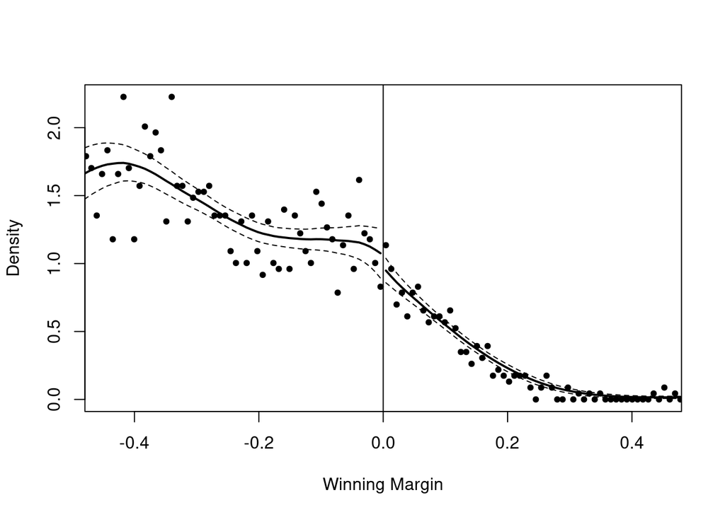

```r
title(xlab="Winning Margin",ylab="Density") # add labels (always add labels. Really. Always.)
abline(v=0, lty=1)
```

The test provides relatively clear visual evidence that sorting is not a problem in this case. There is a clear overlap of the confidence intervals at the cut-off, so the continuity assumption holds. This command also provides statistical tests. You can see that information on the individual cells - or bins - and the occurrence of observations within them if you turn `ext.out=TRUE`. For now, we focus on the inference test for sorting. The p-value of about `0.52` makes clear that we do not reject the null hypothesis of continuity at the cut-off.

Let’s further explore the structure of our data and check if sorting really isn’t a problem here. Recall, we want to make sure the density of units should be continuous near the cut-off. We can use the `rddensity` package to do so. This package applies a different test than the one we used before. It also is somewhat more useful as it provides additional information.

The command is straightforward. You only have to insert the running variable as argument and, if different from 0, the cut-off. Note that you can optionally specify bandwidths, as above, using the `h` argument. Otherwise, an optimal bandwidth will be specified automatically. You can then save this as an object and run the `summary` command to see the output.

**Exercise 17: Examine the density of the running variable using the `rddensity` command. Interpret your findings. Are they equivalent to those in the previous exercise?**

**Reveal Answer**

```r
rdd <- rddensity(educ$margin, c=0)
summary(rdd)
```

```
Manipulation testing using local polynomial density estimation.

Number of obs =       2660
Model =               unrestricted
Kernel =              triangular
BW method =           estimated
VCE method =          jackknife

c = 0                 Left of c           Right of c
Number of obs         2332                328
Eff. Number of obs    769                 314
Order est. (p)        2                   2
Order bias (q)        3                   3
BW est. (h)           0.25                0.282

Method                T                   P > |T|
Robust                -0.9203             0.3574


P-values of binomial tests (H0: p=0.5).

Window Length / 2          <c     >=c    P>|T|
0.004                      11       9    0.8238
0.009                      18      26    0.2912
0.013                      32      34    0.9022
0.017                      42      48    0.5984
0.021                      52      58    0.6338
0.026                      68      63    0.7269
0.030                      76      73    0.8699
0.034                      97      82    0.2954
0.038                     116      89    0.0691
0.043                     134      93    0.0078
```

This output indicates we are in the clear. Note that the test is based on *quadratic* local polynomial functions. We also get a different bandwidth - recall that we are solely looking at the density of the running variable here.

Importantly, the test reveals a p-value of `0.357`. We again do not reject the null hypothesis of continuity around the cut-off. Both tests indicating the same result gives us confidence in doing so.

The second part of the output indicates the results of binomial tests for the allocation of observations around the cut-off for different windows. The number of observations is indicated as well as individual p-values for significance tests, with the null hypothesis being equal distribution on either side of the cut-off. Note that this can give us an indication, but modest imbalance - at such disaggregate level - is not evidence for sorting, especially if there is a meaningful difference in the overall number of treated and control units.

Let’s now plot this density test, too. The `rdplotdensity` function allows us to do so easily. It uses the results of the test conducted in `rddensity`. The syntax is simple:

```r
rdplotdensity([rdd_object] ,[running_var])
```

We can also add some useful arguments. Feel free to adjust your plot:

| Argument | Description |
| --- | --- |
| `plotRange` | Indicates starting and end point of plot |
| `plotN` | Number of grid points used on either side of the cutoff |
| `CIuniform` | True or False. If true, CI are displayed as continuous bands |

**Exercise 18: Use the `rplotdensity` function to conduct a visual density check in a data range from `-0.2` to `0.2`.**

**Reveal Answer**

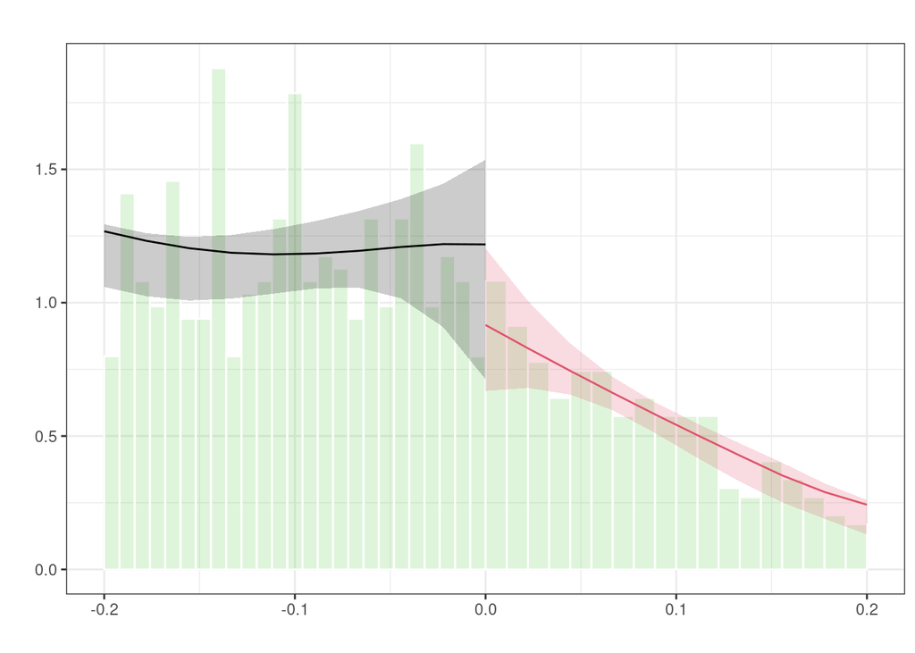

```r
plot_rdd <- rdplotdensity(rdd,educ$margin, plotRange = c(-.2, 0.2),  CIuniform = TRUE)
```

Again, we find visual evidence for continuity around the cutoff. Now we can be confident about sorting not being a problem with this data set.

### Balance

One important falsification test is examining whether, near the cut-off, treated units are similar to control units in terms of observable characteristics. The logic of this test is based on the idea that if units cannot manipulate the score they receive, there should not be systematic differences between untreated and treated units with similar values of the score - in other words, treated and untreated units directly around the cut-off should, in expectation, have the same potential outcomes (i.e., treatment is independent of potential outcomes).

**Exercise 19: Let’s check for balance around the cutoff. Use the `rdrobust()` function. Set the cut-off argument `c` equal to 0, and the `bwselect` argument equal to “mserd”. In this case, the outcome variables are the covariates that we want to check for balance. Check if there is balance for the following covariates: `log_pop`, `school_men`, `sex_ratio`, `log_area`. Remember to use the `summary()` function to report results.**

**Reveal Answer**

```r
summary(rdrobust(educ$log_pop, educ$margin, c=0, bwselect="mserd"))
```

```
Call: rdrobust

Number of Obs.                 2660
BW type                       mserd
Kernel                   Triangular
VCE method                       NN

Number of Obs.                 2332          328
Eff. Number of Obs.             385          232
Order est. (p)                    1            1
Order bias  (q)                   2            2
BW est. (h)                   0.122        0.122
BW bias (b)                   0.195        0.195
rho (h/b)                     0.627        0.627
Unique Obs.                    2330          328

=============================================================================
        Method     Coef. Std. Err.         z     P>|z|      [ 95% C.I. ]
=============================================================================
  Conventional     0.013     0.290     0.045     0.964    [-0.555 , 0.581]
        Robust         -         -     0.005     0.996    [-0.676 , 0.680]
=============================================================================
```

```r
summary(rdrobust(educ$school_men, educ$margin, c=0, bwselect="mserd"))
```

```
Call: rdrobust

Number of Obs.                 2632
BW type                       mserd
Kernel                   Triangular
VCE method                       NN

Number of Obs.                 2317          315
Eff. Number of Obs.             373          222
Order est. (p)                    1            1
Order bias  (q)                   2            2
BW est. (h)                   0.121        0.121
BW bias (b)                   0.187        0.187
rho (h/b)                     0.646        0.646
Unique Obs.                    2315          315

=============================================================================
        Method     Coef. Std. Err.         z     P>|z|      [ 95% C.I. ]
=============================================================================
  Conventional     0.013     0.014     0.916     0.360    [-0.015 , 0.040]
        Robust         -         -     0.747     0.455    [-0.021 , 0.046]
=============================================================================
```

```r
summary(rdrobust(educ$sex_ratio, educ$margin, c=0, bwselect="mserd"))
```

```
Call: rdrobust

Number of Obs.                 2659
BW type                       mserd
Kernel                   Triangular
VCE method                       NN

Number of Obs.                 2331          328
Eff. Number of Obs.             333          206
Order est. (p)                    1            1
Order bias  (q)                   2            2
BW est. (h)                   0.106        0.106
BW bias (b)                   0.191        0.191
rho (h/b)                     0.554        0.554
Unique Obs.                    2329          328

=============================================================================
        Method     Coef. Std. Err.         z     P>|z|      [ 95% C.I. ]
=============================================================================
  Conventional     0.017     0.019     0.920     0.357    [-0.020 , 0.055]
        Robust         -         -     1.006     0.314    [-0.021 , 0.065]
=============================================================================
```

```r
summary(rdrobust(educ$log_area, educ$margin, c=0, bwselect="mserd"))
```

```
Call: rdrobust

Number of Obs.                 2642
BW type                       mserd
Kernel                   Triangular
VCE method                       NN

Number of Obs.                 2320          322
Eff. Number of Obs.             352          214
Order est. (p)                    1            1
Order bias  (q)                   2            2
BW est. (h)                   0.112        0.112
BW bias (b)                   0.185        0.185
rho (h/b)                     0.607        0.607
Unique Obs.                    2318          322

=============================================================================
        Method     Coef. Std. Err.         z     P>|z|      [ 95% C.I. ]
=============================================================================
  Conventional     0.029     0.234     0.124     0.901    [-0.431 , 0.489]
        Robust         -         -     0.045     0.964    [-0.534 , 0.559]
=============================================================================
```

We observe that there is balance across all the covariates of interest - we have no reason to believe that units differ systematically.

### Placebo cut-offs

Another falsification test is to identify treatment effects at artificial or placebo cut-off values. Recall from the lecture that one of the identifying assumptions is the continuity of potential outcomes for the treated and control units around the cut-off. While we cannot empirically test this assumption, we can test for continuity away from the threshold. Although this does not imply the continuity assumption holds at the cut-off, it helps to rule out the presence of discontinuities other than the cut-off. Thus, this is not a hard test but can lend plausibility to our research design.

This test implies looking at the outcome variable but using different cut-offs where we should **not** expect changes in the outcome. Thus, the estimates from this test should be near zero (and not statistically significant). One **important** step before conducting this type of test is that you need to split the sample between those units observations above the cut-off and those below. We do this to avoid *contamination* due to the real treatment effects. It also ensures that the analysis of each placebo cut-off is conducted using only observations with the same treatment status.

**Exercise 20: Conduct placebo cut-off tests using the placebo values of `-0.20` and `-0.25` for placebo tests below the cut-off. Conduct the same test above the cut-off using the following placebo values: `0.20`, and `0.25`. Use the `rdrobust()` function to perform this test. Set the argument `bwselect` equal to “mserd”. Replace the cut-off argument `c` with the values listed before. Use the `summary()` function to report the results. Remember to create two new data frames first. You can simply subset the original data frame, or use the filter function from tidyverse to do this.**

| Function/argument | Description |
| --- | --- |
| `new_data <- data` | Creates a new data frame using the conditions set following the pipeline operator `%>%` |
| `filter(variable == "condition")` | Subset the data based on a logical operation |

```r
new_data <- data %>%
  filter(variable >= 0)
```

**Reveal Answer**

```r
educ_above <- educ %>%
  filter(margin >= 0)

educ_below <- educ %>%
  filter(margin < 0)

summary(rdrobust(educ_above$school_women, educ_above$margin, c=0.2, bwselect = "mserd")) # -0.044
```

```
Call: rdrobust

Number of Obs.                  315
BW type                       mserd
Kernel                   Triangular
VCE method                       NN

Number of Obs.                  280           35
Eff. Number of Obs.              38           14
Order est. (p)                    1            1
Order bias  (q)                   2            2
BW est. (h)                   0.053        0.053
BW bias (b)                   0.093        0.093
rho (h/b)                     0.577        0.577
Unique Obs.                     280           35

=============================================================================
        Method     Coef. Std. Err.         z     P>|z|      [ 95% C.I. ]
=============================================================================
  Conventional    -0.044     0.034    -1.287     0.198    [-0.112 , 0.023]
        Robust         -         -    -1.022     0.307    [-0.122 , 0.038]
=============================================================================
```

```r
summary(rdrobust(educ_above$school_women, educ_above$margin, c=0.25, bwselect="mserd")) #-0.025
```

```
Call: rdrobust

Number of Obs.                  315
BW type                       mserd
Kernel                   Triangular
VCE method                       NN

Number of Obs.                  294           21
Eff. Number of Obs.              24           10
Order est. (p)                    1            1
Order bias  (q)                   2            2
BW est. (h)                   0.066        0.066
BW bias (b)                   0.119        0.119
rho (h/b)                     0.560        0.560
Unique Obs.                     294           21

=============================================================================
        Method     Coef. Std. Err.         z     P>|z|      [ 95% C.I. ]
=============================================================================
  Conventional    -0.025     0.067    -0.380     0.704    [-0.156 , 0.105]
        Robust         -         -    -0.323     0.747    [-0.185 , 0.133]
=============================================================================
```

```r
summary(rdrobust(educ_below$school_women, educ_below$margin, c=-0.2, bwselect="mserd")) # 0.063
```

```
Call: rdrobust

Number of Obs.                 2315
BW type                       mserd
Kernel                   Triangular
VCE method                       NN

Number of Obs.                 1707          608
Eff. Number of Obs.             105           96
Order est. (p)                    1            1
Order bias  (q)                   2            2
BW est. (h)                   0.034        0.034
BW bias (b)                   0.064        0.064
rho (h/b)                     0.542        0.542
Unique Obs.                    1705          608

=============================================================================
        Method     Coef. Std. Err.         z     P>|z|      [ 95% C.I. ]
=============================================================================
  Conventional     0.063     0.030     2.081     0.037     [0.004 , 0.123]
        Robust         -         -     2.172     0.030     [0.007 , 0.142]
=============================================================================
```

```r
summary(rdrobust(educ_below$school_women, educ_below$margin, c=-0.25, bwselect="mserd")) # -0.008
```

```
Call: rdrobust

Number of Obs.                 2315
BW type                       mserd
Kernel                   Triangular
VCE method                       NN

Number of Obs.                 1560          755
Eff. Number of Obs.             430          308
Order est. (p)                    1            1
Order bias  (q)                   2            2
BW est. (h)                   0.106        0.106
BW bias (b)                   0.160        0.160
rho (h/b)                     0.663        0.663
Unique Obs.                    1558          755

=============================================================================
        Method     Coef. Std. Err.         z     P>|z|      [ 95% C.I. ]
=============================================================================
  Conventional    -0.008     0.015    -0.506     0.613    [-0.037 , 0.022]
        Robust         -         -    -0.371     0.711    [-0.041 , 0.028]
=============================================================================
```

We find that for almost all the placebo cut-off values, the coefficients are all nearly zero and not statistically significant with the exception of -0.2, which we would want to investigate further: this could be a statistical artifact or indicate something may happen at a vote share of about 40% for Islamic parties. We could run further statistical tests to see if this is only due to chance are actually remains a robust difference. Context would ideally tell us if there is some other rule or aspect at the vote share that commonly with this margin of vote that may induce some variation in the outcome.

Overall, however, this evidence suggests that there are no frequent jumps in the data, indicating that the continuity assumption is likely to hold in this case.